# ANÁLISIS DE COMPONENTES PRINCIPALES DE INDICADORES CANTONALES SOBRE LA NIÑEZ EN COSTA RICA (PRINCIPAL COMPONENTS ANALYSIS OF CANTONAL INDICATORS ON CHILDREN IN COSTA RICA)

JOSÉ M. GÓMEZ

2022-05-25

#1. INTRODUCCIÓN

El presente trabajo empírico, correspondiente a la primera presentación de la materia “Introducción al Análisis Multivariado” estudia descriptivamente (i.e., sin conclusiones definitivas ni causalmente vinculantes) diversos indicadores sociales de nutrición y cuidados médicos para 81 cantones de Costa Rica en el año 2019.

#2. MATERIALES Y MÉTODOS

##2.1. Tipo de Investigación

##2.2. Diseño de la Investigación

Cuantitativa

##2.3. Alcance de la Investigación

Descriptiva.

##2.4. Muestra

Datos de los 81 cantones de Costa Rica para el año 2019 sobre los siguientes indicadores sociales relativos a nutrición y cuidados médicos: a) Prevalencia de desnutrición infantil (1 mayor prevalencia ; 5 menor prevalencia). b) Prevalencia de sobrepeso y obesidad infantil (1 mayor prevalencia ; 5 menor prevalencia). c) Tasa de vacunación (cobertura bruta %). d) Acceso a redes de cuido de personas de tercera edad (tasa de centros de cuido por 100,000 personas de la población objetivo). e) Mortalidad infantil (muertes por 1,000 nacimientos).

En epidemiología, la prevalencia es la proporción de personas que sufren una enfermedad con respecto al total de la población en estudio.

##2.5. Instrumentos

Análisis de Componentes Principales (PCA), Análisis de Conglomerados Jerárquicos y Análisis de Conglomerados por K-medias.

#3. CONCEPTUALIZACIÓN

1. Librería factoextra Proporciona algunas funciones fáciles de usar para extraer y visualizar la salida de análisis de datos multivariados, incluidos ‘PCA’ (Análisis de componentes principales), ‘CA’ (Análisis de correspondencia), ‘MCA’ (Análisis de correspondencia múltiple), ‘FAMD’ ( Análisis factorial de datos mixtos), funciones ‘MFA’ (Análisis factorial múltiple) y ‘HMFA’ (Análisis jerárquico factorial múltiple) de diferentes paquetes de R. También contiene funciones para simplificar algunos pasos del análisis de agrupamiento y proporciona una elegante visualización de datos basada en ‘ggplot2’.
2. cos2 (coseno cuadrado) Se utiliza como medida de calidad en la representación de los individuos. Asumiendo que los individuos cuyo coseno cuadrado sea mayor a 0.50 son representativos, se concluiría que todos los individuos alrededor del origen estarían mal representados por el modelo generado vía PCA
3. Gráfica de Sedimentación Señala (Minitab, 2019) que “(…) un gráfico de sedimentación muestra el número del componente principal versus su valor propio correspondiente. La gráfica de sedimentación ordena los valores propios desde el más grande hasta el más pequeño. Los valores propios de la matriz de correlación son iguales a las varianzas de los componentes principales.” Esta gráfica sirve para seleccionar el número de componentes que se usarán con base en la magnitud (el “tamaño”) de los valores característicos. El patrón ideal es una curva pronunciada, seguida de una inflexión y luego de una línea recta. Se deben utilizar los componentes en la curva pronunciada antes del primer punto que inicia la tendencia de línea.
4. Autovalores Magnitudes numéricas obtenidas como la derivada de la función evaluada en un punto (pendiente de cada predictor, en este caso la pendiente de cada variable dividida entre la distancia máxima o hipotenusa) divididos entre la corrección de Bessel n-1 (corrección que convierte a la varianza en una variación alrededor del origen). Expresan la variación que el PC_i al que correspondan explica del conjunto de datos estudiado.
5. Análisis de Componentes Principales Como señala (I. T. Jollife, Principal Component Analysis, 2002, p.1), es una metodología estadística que busca reducir la dimensionalidad de un conjunto de datos que posee un gran número de variables interrelacionadas logrando retener tanto como sea posible la variabilidad actualmente presente en el conjunto de datos estudiado, puesto que esto implica que la distribución de tal conjunto de datos dentro del espacio muestral tras realizar la transformación ortogonal será isométricamente equivalente a la distribución del conjunto de datos original.
6. Análisis de Conglomerados Como se señala en (Hennig, Christian; Meila, Marina; Murtagh, Fionn; Rocci, Roberto, Handbook of Cluster Analysis, 2016, p.2), formalmente, dado un conjunto de objetos, también llamado conjunto de datos, cuya estructura se define como D={x_1,…,x_n} y contiene n-ésimos puntos de datos u observaciones, la tarea de construir conglomerados con los elementos x_i∈D consiste en agrupar tales elementos en K-ésimos conjuntos (y en función si tales conjuntos son disjuntos o no, es que se trata de clústeres particionales o clústeres jerárquicos o traslapados) pertenecientes a D, denotados estos como C_1,…,C_k. Un conglomerado es, como primera aproximación, cada una de las particiones obtenidas, esto es, C={C_1,…,C_k}.

El número de clústeres es, en caso de utilizar en el análisis de conglomerados, dimensiones generadas mediante algún embebimiento métrico (por ejemplo, el realizado vía PCA en esta investigación), la cantidad de conglomerados bajo los cuales se agruparán las observaciones contenidas en las dos dimensiones generadas por el embebimiento métrico de tipo PCA.

7. Análisis de Conglomerados Jerárquicos

Como se señala en https://www.displayr.com/what-is-hierarchical-clustering/, el agrupamiento jerárquico comienza tratando cada observación como un grupo separado. Luego, ejecuta repetidamente los siguientes dos pasos: 1) Identifica los dos clústeres que están más cerca entre sí, 2) Fusiona los dos clústeres más similares. Este proceso iterativo continúa hasta que todos los clústeres se fusionan.

El método de validación de conglomerados jerárquicos utilizado aquí, expresada en la función pvclust, es un método semi no-supervisado (desde el marco conceptual de la teoría del aprendizaje estadístico), lo que traslado al lenguaje de la estadística clásica sería equivalente a estadística semi descriptiva. Con la sintaxis pvpick, de la misma librería que pvclust, se encuentran los clústeres con valores p relativamente altos/bajos (según los criterios preestablecidos por el investigador, tal como se verá en la sección relativa a la estimación de los conglomerados jerárquicos significativos). Los componentes de la sintaxis pvpick son: a) “alpha” es el valor mínimo de una magnitud a partir de cual se produce un efecto determinado. “pv” es una cadena de caracteres que especifica el valor p que se utilizará. Debe ser uno de “si”, “au” y “bp”, correspondiente a SI, valor p de AU y valor de BP, respectivamente. b) “tipo” es uno de “geq”, “leq”, “gt” o “lt”. Si se especifica “geq”, se devuelven o muestran los clústeres con un valor p mayor o igual al umbral dado por “alfa”. Del mismo modo, “leq” significa menor que o igual, “gt” mayor que y “lt” menor que el valor umbral. El valor predeterminado es “geq”. c) “max.only” es un valor lógico. Si algunos de los clústeres con valores p altos/bajos tienen una relación de inclusión, solo se devuelve (o muestra) el clúster más grande cuando max.only=TRUE.

Como se señala en https://stackoverflow.com/questions/43576210/p-values-in-pvclust-results-in-hclust, los métodos utilizados por pvclust tienen su origen en el análisis filogenético en el que intenta agrupar individuos de diferentes especies en función de su ADN u otras características. Sin embargo, el caso filogenético o genómico es un poco peculiar. En esta situación, las observaciones/muestras son los individuos (fuente del ADN) y las variables/características/descriptores son por ejemplo los genes o su nivel de expresión. En este caso, tiene sentido agrupar a los individuos en función de sus genes y probar la estabilidad de los grupos arrancando los genes porque los genes son múltiples y es razonable volver a muestrear al azar dentro del conjunto de genes.

La interpretación de BP (probabilidad bootstrapping) es bastante sencilla. En el ejemplo, pvclust remuestreará las columnas del conjunto de datos, que son aquí los indicadores analizados (o, en caso se utilicen las nuevas dimensiones generadas vía algún embebimiento métrico, para este caso PCA, las nuevas variables analizadas, que son algo así como indicadores compuestos), es decir, que algunas columnas se eliminarán y otras aparecerán más de una vez (por la naturaleza de la técnica boostrapping, que genera isometrías al conjunto de datos original, de ahí que se genere un tensor). Luego, volverá a calcular la distancia euclidiana entre las filas (cantones) y construirá el dendrograma. Repetirá esto nboot*length(r) veces [length(r) = 10 por defecto] y para cada ejecución verificará para cada grupo si el mismo conjunto de cantones está presente en un grupo del conjunto de datos de arranque.

8. Análisis de Conglomerados por K-Medias Como se señala en https://marxianstatistics.files.wordpress.com/2020/12/sobre-los-estimadores-de-bayes-el-analisis-de-grupos-y-las-mixturas-gaussianas-isadore-nabi.pdf, un análisis de conglomerados por K-medias es un método de cuantización vectorial (técnica que permite modelar las funciones de densidad de probabilidad de un conjunto de datos usando la función de distribución acumulada de los vectores prototipo -elemento del espacio muestral que representa a un grupo de elementos de dicho espacio-) que busca particionar n observaciones en k grupos en los que cada observación pertenece al grupo con la media más cercana (que representa el centro o centroide del grupo desde la perspectiva geométrica), siendo precisamente tales medias el vector prototipo de cada k-ésimo grupo. Esto pertenece a las técnicas de clasificación del aprendizaje automático (machine learning).
9. Validación de Agrupamientos Como se señala en https://www.datanovia.com/en/lessons/determining-the-optimal-number-of-clusters-3-must-know-methods/, Determinar el número óptimo de conglomerados en un conjunto de datos es un tema fundamental en el agrupamiento de particiones, como el agrupamiento de k-medias, que requiere que el usuario especifique el número de conglomerados k que se generarán.

Estos métodos incluyen métodos directos y métodos de prueba estadísticos.

Los métodos directos consisten en optimizar un criterio, como las sumas de cuadrados dentro de un grupo o la silueta promedio; entre estos dos métodos, como se indica en https://towardsdatascience.com/silhouette-method-better-than-elbow-method-to-find-optimal-clusters-378d62ff6891, es más robusto el método de la silueta. Los métodos correspondientes se denominan métodos de codo y silueta, respectivamente. Por su parte, los métodos estadísticos de prueba consisten en comparar la evidencia contra la hipótesis nula. Un ejemplo es el método del estadístico de la brecha. La desventaja de los métodos de codo y silueta promedio es que solo miden una característica de agrupación global. Un método más sofisticado es usar la estadística de brecha que proporciona un procedimiento estadístico para formalizar la heurística (la técnica de indagación y de descubrimiento) de los métodos codo y silueta para estimar el número óptimo de grupos.

Además de los métodos estadísticos de codo (Elbow), silueta y brecha, se han publicado más de treinta índices y métodos para identificar el número óptimo de grupos. En esta investigación se utilizará una función que permite calcular todos estos 30 índices y decidir el número óptimo de conglomerados utilizando la “regla de la mayoría”. La regla de la mayoría es una regla de decisión que selecciona el número óptimo de clústeres escogido por la mayoría de los 30 criterios utilizados, concluyendo que el mejor número de clústeres es aquel por el que más criterios de entre los 30 utilizados se decantan.

Para el caso del método de la silueta, la puntuación de la silueta se encuentra dentro del rango [-1, 1]. La puntuación de silueta de 1 significa que los conglomerados son muy densos y bien separados. La puntuación de 0 significa que los clústeres se superponen (no están bien separados). La puntuación de menos de 0 significa que los datos pertenecientes a los clústeres pueden ser erróneos/incorrectos (mal separados).

10. Establecer Semilla (set.seed) Como se señala en https://r-coder.com/set-seed-r/, cuando se generan “números aleatorios” en R, en realidad se están generando números pseudoaleatorios. Estos números se generan con un algoritmo que requiere una semilla o valor inicial para inicializar. Que los números sean pseudo-aleatorio en lugar de “aleatorios puros” (la aleatoriedad objetivamente no existe, es decir, no es una característica intrínseca de la Naturaleza, sino únicamente un recurso cognitivo que el intelecto humano utiliza para aproximarse a la verdad) significa que, si se conoce la semilla y el generador de tales números, se puede predecir (y reproducir) la salida. La relevancia de configurar una semilla (por ejemplo, con la sintaxis set.seed que aquí se utilizará), cómo funciona set.seed y cómo configurar o desactivar la semilla, reside en la reproductibilidad de los resultados de la investigación científica. Establecer una semilla en R u otro programa computacional significa inicializar un generador de números pseudoaleatorios. La mayoría de los métodos de simulación en Estadística requieren la posibilidad de generar números pseudoaleatorios que imiten las propiedades de generaciones independientes de una distribución uniforme en el intervalo (0,1). Para obtener estas secuencias de números pseudoaleatorios, se necesita un algoritmo recursivo llamado Generador de Números Aleatorios (RNG), por ejemplo, la sintaxis “rnorm(X)”. Sin embargo, si se ejecuta esta sintaxis u otra, sin instrucciones adicionales, se obtendrá una salida diferente. Esto implica que el código no es reproducible, porque no conoce la semilla que R usó para generar esa secuencia. Así, establecer una semilla en R se usa para: 1) reproducir el mismo resultado de los estudios de simulación, 2) ayudar a depurar el código cuando se trata de números pseudoaleatorios. Al llamar a una función de generación de números aleatorios, la salida depende de los valores de “.Random.seed”, que cambia después de ejecutar estas funciones. Si almacena el valor de “.Random.seed”, se puede obtener el estado inicial actual. En consecuencia, en caso de que se desee generar los mismos números una K cantidad de veces, se debe configurar la misma semilla K veces, por ejemplo, set.seed(123).

#4. RESULTADOS EMPÍRICOS

```r
#4.1. ANÁLISIS DESCRIPTIVO GENERAL

##Cargando el conjunto de datos tomado del INCAE, quienes a su vez señalan en su página web (https://www.incae.edu/es/clacds/proyectos/indice-de-progreso-social-cantonal-2019.html) que los construyen Utilizando 53 indicadores sociales y ambientales de fuentes públicas; sin embargo, no señalan las fuentes específicas de cada uno de los indicadores.
library(readxl)
DATOSCLUSTER <- read_excel("DATOSCLUSTER.xlsx",
    col_types = c("text", "numeric", "numeric",
        "numeric", "numeric", "numeric"))
View(DATOSCLUSTER)
DATA <- DATOSCLUSTER[,2:6]
summary(DATA)
```

```
##  Desnutrición infantil Tasa de vacunación Sobrepeso y obesidad infantil
##  Min.   :1.000         Min.   : 70.66     Min.   :1.000
##  1st Qu.:3.000         1st Qu.: 90.49     1st Qu.:2.000
##  Median :4.000         Median : 97.22     Median :3.000
##  Mean   :3.444         Mean   : 97.02     Mean   :2.679
##  3rd Qu.:4.000         3rd Qu.:102.96     3rd Qu.:3.000
##  Max.   :4.000         Max.   :135.71     Max.   :4.000
##  Acceso a redes de cuido personas de tercera edad Mortalidad Infantil
##  Min.   : 0.000                                   Min.   : 0.000
##  1st Qu.: 0.000                                   1st Qu.: 6.219
##  Median : 8.664                                   Median : 7.678
##  Mean   : 6.437                                   Mean   : 8.251
##  3rd Qu.:11.396                                   3rd Qu.: 9.950
##  Max.   :16.162                                   Max.   :22.642
```

```r
##En promedio, un 80% de los infantes muestreados no sufre de desnutrición, la tasa de vacunación es en promedio elevada (97.02%), es preocupante el valor promedio del indicador de sobrepeso y obesidad infantil (2.679, que indica que hay que mejorar los hábitos alimenticios, la calidad de alimentación y la cultura hacia el deporte u otros tipos de actividad física para la población infantil), nuestros ancianos y ancianas no reciben el cuido adecuado (en promedio apenas un 6.437% de cada 100,000 ancianos) y la tasa de mortalidad infantil es en promeido baja (de 8.251%, sin embargo, puede y debe ser menor, lo que requiere del acompañamiento de políticas públicas en materia de acceso a condiciones materiales de existencia óptimas y mejoramiento de las instituciones de salud). Salvo la tasa de vacunación, que parecería distribuirse normalmente en una primera mirada (porque su media y su mediana son muy similares), no parece que ninguna otra variable siga esa misma distribución.

##Es recomendable escalar (no debe confundirse con estandarizar) la base de datos porque la técnica de PCA combina las variables para generar las nuevas dimensiones en las cuales se realiza el embebimiento métrico del espacio muestral original y para que esta mezcla de variables se realice de la forma más adecuada, dado que en tal combinación se mezclarán sus escalas de medida originales, es necesaria la escalación de las mismas bajo una escala común, que para el caso de la sintaxis scale(X) es el número de columnas de X (véase la documentación de R relativa a dicha sintaxis).
sDATA <- scale(DATA)
View(sDATA)
summary(sDATA)
```

```
##  Desnutrición infantil Tasa de vacunación Sobrepeso y obesidad infantil
##  Min.   :-2.8709       Min.   :-2.6125    Min.   :-2.0130
##  1st Qu.:-0.5220       1st Qu.:-0.6473    1st Qu.:-0.8141
##  Median : 0.6525       Median : 0.0199    Median : 0.3848
##  Mean   : 0.0000       Mean   : 0.0000    Mean   : 0.0000
##  3rd Qu.: 0.6525       3rd Qu.: 0.5889    3rd Qu.: 0.3848
##  Max.   : 0.6525       Max.   : 3.8361    Max.   : 1.5838
##  Acceso a redes de cuido personas de tercera edad Mortalidad Infantil
##  Min.   :-1.0887                                  Min.   :-1.8518
##  1st Qu.:-1.0887                                  1st Qu.:-0.4561
##  Median : 0.3768                                  Median :-0.1288
##  Mean   : 0.0000                                  Mean   : 0.0000
##  3rd Qu.: 0.8389                                  3rd Qu.: 0.3813
##  Max.   : 1.6450                                  Max.   : 3.2296
```

```r
#4.2. GENERACIÓN DE LOS COMPONENTES PRINCIPALES Y GRÁFICA DE SEDIMENTACIÓN

library("FactoMineR")
res.pca <- PCA(X = sDATA, scale.unit = TRUE,graph = FALSE) #Aquí sí se estandariza el conjunto de datos (media nula y varianza unitaria)
summary(res.pca)
```

```
##
## Call:
## PCA(X = sDATA, scale.unit = TRUE, graph = FALSE)
##
##
## Eigenvalues
##                        Dim.1   Dim.2   Dim.3   Dim.4   Dim.5
## Variance               1.552   1.188   0.901   0.731   0.628
## % of var.             31.044  23.759  18.028  14.616  12.554
## Cumulative % of var.  31.044  54.803  72.830  87.446 100.000
##
## Individuals (the 10 first)
##                                                      Dist    Dim.1    ctr
## 1                                                |  1.936 | -0.539  0.231
## 2                                                |  1.692 |  0.340  0.092
## 3                                                |  1.554 | -0.373  0.110
## 4                                                |  2.459 |  0.352  0.099
## 5                                                |  3.248 |  3.030  7.300
## 6                                                |  1.586 |  0.816  0.530
## 7                                                |  2.213 | -0.077  0.005
## 8                                                |  1.761 | -0.442  0.155
## 9                                                |  1.757 | -0.296  0.070
## 10                                               |  1.470 |  1.388  1.533
##                                                    cos2    Dim.2    ctr   cos2
## 1                                                 0.077 | -1.138  1.346  0.346
## 2                                                 0.040 | -1.358  1.917  0.644
## 3                                                 0.057 | -1.256  1.639  0.653
## 4                                                 0.021 | -1.494  2.321  0.369
## 5                                                 0.870 |  0.923  0.885  0.081
## 6                                                 0.265 | -1.052  1.150  0.440
## 7                                                 0.001 |  0.557  0.322  0.063
## 8                                                 0.063 | -1.168  1.417  0.439
## 9                                                 0.028 | -1.450  2.184  0.680
## 10                                                0.892 | -0.260  0.070  0.031
##                                                     Dim.3    ctr   cos2
## 1                                                | -0.723  0.715  0.139 |
## 2                                                |  0.420  0.242  0.062 |
## 3                                                | -0.490  0.329  0.100 |
## 4                                                |  1.329  2.420  0.292 |
## 5                                                | -0.334  0.153  0.011 |
```

[output cut: 10 more lines]

```
## Sobrepeso y obesidad infantil                    |  0.472 14.377  0.223 |
## Acceso a redes de cuido personas de tercera edad | -0.683 30.032  0.466 |
## Mortalidad Infantil                              |  0.729 34.242  0.531 |
##                                                   Dim.2    ctr   cos2    Dim.3
## Desnutrición infantil                            -0.603 30.625  0.364 |  0.318
## Tasa de vacunación                                0.527 23.423  0.278 |  0.790
## Sobrepeso y obesidad infantil                     0.677 38.586  0.458 | -0.276
## Acceso a redes de cuido personas de tercera edad  0.102  0.873  0.010 | -0.316
## Mortalidad Infantil                               0.278  6.493  0.077 | -0.021
##                                                     ctr   cos2
## Desnutrición infantil                            11.201  0.101 |
## Tasa de vacunación                               69.201  0.624 |
## Sobrepeso y obesidad infantil                     8.470  0.076 |
## Acceso a redes de cuido personas de tercera edad 11.082  0.100 |
## Mortalidad Infantil                               0.047  0.000 |
```

```r
library(factoextra)
```

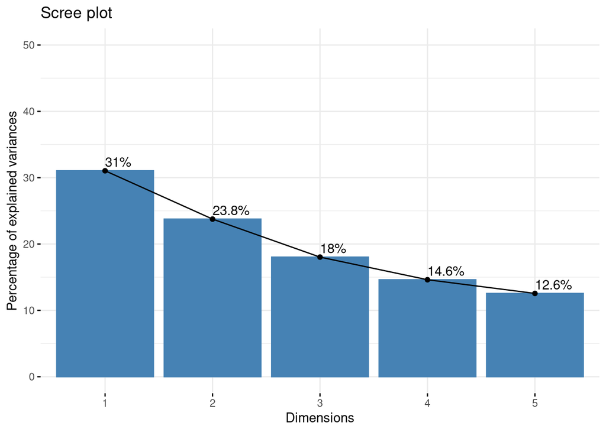

```r
autovalores = get_eigenvalue(res.pca)
fviz_screeplot(res.pca,addlabels = TRUE,ylim = c(0,50))
```

```r
#4.3. SELECCIÓN DE COMPONENTES PRINCIPALES
res.pca$var$contrib #Contribución de variables a cada nueva dimensión conformada (en este caso, la sintaxis conformó automáticamente 5 dimensiones).
```

```
##                                                      Dim.1      Dim.2
## Desnutrición infantil                            15.960901 30.6247998
## Tasa de vacunación                                5.389067 23.4233013
## Sobrepeso y obesidad infantil                    14.376567 38.5864091
## Acceso a redes de cuido personas de tercera edad 30.031653  0.8727096
## Mortalidad Infantil                              34.241812  6.4927802
##                                                        Dim.3      Dim.4
## Desnutrición infantil                            11.20081182 21.8420137
## Tasa de vacunación                               69.20094430  1.8010394
## Sobrepeso y obesidad infantil                     8.46959122  0.0415798
## Acceso a redes de cuido personas de tercera edad 11.08173133 57.6509581
## Mortalidad Infantil                               0.04692134 18.6644090
##                                                      Dim.5
## Desnutrición infantil                            20.371474
## Tasa de vacunación                                0.185648
## Sobrepeso y obesidad infantil                    38.525853
## Acceso a redes de cuido personas de tercera edad  0.362948
## Mortalidad Infantil                              40.554077
```

```r
res.pca$var$contrib
```

```
##                                                      Dim.1      Dim.2
## Desnutrición infantil                            15.960901 30.6247998
## Tasa de vacunación                                5.389067 23.4233013
## Sobrepeso y obesidad infantil                    14.376567 38.5864091
## Acceso a redes de cuido personas de tercera edad 30.031653  0.8727096
## Mortalidad Infantil                              34.241812  6.4927802
##                                                        Dim.3      Dim.4
## Desnutrición infantil                            11.20081182 21.8420137
## Tasa de vacunación                               69.20094430  1.8010394
## Sobrepeso y obesidad infantil                     8.46959122  0.0415798
## Acceso a redes de cuido personas de tercera edad 11.08173133 57.6509581
## Mortalidad Infantil                               0.04692134 18.6644090
##                                                      Dim.5
## Desnutrición infantil                            20.371474
## Tasa de vacunación                                0.185648
## Sobrepeso y obesidad infantil                    38.525853
## Acceso a redes de cuido personas de tercera edad  0.362948
## Mortalidad Infantil                              40.554077
```